# Practical Machine Learning assignment

Ron Collins

July 1, 2016

### Practical Machine Learning/ Prediction Assignment

## Background

Using devices such as Jawbone Up, Nike FuelBand, and Fitbit it is now possible to collect a large amount of data about personal activity relatively inexpensively. These type of devices are part of the quantified self movement – a group of enthusiasts who take measurements about themselves regularly to improve their health, to find patterns in their behavior, or because they are tech geeks. One thing that people regularly do is quantify how much of a particular activity they do, but they rarely quantify how well they do it. In this project, my goal is be to use data from accelerometers on the belt, forearm, arm, and dumbell of 6 participants. They were asked to perform barbell lifts correctly and incorrectly in 5 different ways. More information is available from the website here: http://groupware.les.inf.puc-rio.br/har (see the section on the Weight Lifting Exercise Dataset).

Ugulino, W.; Cardador, D.; Vega, K.; Velloso, E.; Milidiu, R.; Fuks, H. Wearable Computing: Accelerometers’ Data Classification of Body Postures and Movements. Proceedings of 21st Brazilian Symposium on Artificial Intelligence. Advances in Artificial Intelligence - SBIA 2012. In: Lecture Notes in Computer Science. , pp. 52-61. Curitiba, PR: Springer Berlin / Heidelberg, 2012. ISBN 978-3-642-34458-9. DOI: 10.1007/978-3-642-34459-6_6.

Read more: http://groupware.les.inf.puc-rio.br/har#sbia_paper_section#ixzz4D5o79kNx

## Goal

The goal of this project is to predict the manner in which they did the exercise. This is the “classe” variable in the training set. You may use any of the other variables to predict with. You should create a report describing how you built your model, how you used cross validation, what you think the expected out of sample error is, and why you made the choices you did. You will also use your prediction model to predict 20 different test cases.

## loading necessary packages

```r
library(rpart)
library(caret)
library(rattle)
```

```r
library(corrplot)
library(rpart.plot)
library(randomForest)
```

## Data down loading and preprocessing

The training dataset will be split into training and validation datasets for development of the prediction algrothin. The test data set will be used for the project quiz.

# Data down loading.

```r
# Read training data file
trainingData = read.csv("https://d396qusza40orc.cloudfront.net/predmachlearn/pml-training.csv", na.strings=c("", "NA", "NULL"))

dim(trainingData)
```

```
## [1] 19622   160
```

```r
# Read Testing data file
testingData = read.csv("https://d396qusza40orc.cloudfront.net/predmachlearn/pml-testing.csv", na.strings=c("", "NA", "NULL"))
dim(testingData)
```

```
## [1]  20 160
```

# split training data set into training and validation datasets.

```r
inTrain <- createDataPartition(y=trainingData$classe, p=0.7, list=FALSE)
training <- trainingData[inTrain,]
validation <- trainingData[-inTrain,]
dim(training)
```

```
## [1] 13737   160
```

```r
dim(validation)
```

```
## [1] 5885  160
```

Pre-screening of the training dataset

```
From visual inspection of the training dataset it was obvious that a lot of the variables contained missing values which will be removed from the training dataset because they do not contribute information useful for development of the prediction algrothim.  This cleaning decreases the number of variables from 160 to 60.
```

```r
trainingDataScreened <- training[ , colSums(is.na(trainingData)) == 0]

dim(trainingDataScreened)
```

```
## [1] 13737    60
```

From visual inspection of the training dataset it was obvious that the following variables (X, user_name, raw_timestamp_part_1, raw_timestamp_part_2, cvtd_timestamp, new_window, num_window) would not be used in development of the prediction equations. Consequently, they will be removed. This cleaning decreases the number of variables from 60 to 53.

```r
remove = c('X', 'user_name', 'raw_timestamp_part_1', 'raw_timestamp_part_2', 'cvtd_timestamp', 'new_window', 'num_window')
trainingDataRelevent <- trainingDataScreened[, -which(names(trainingDataScreened) %in% remove)]
dim(trainingDataRelevent)
```

```
## [1] 13737    53
```

Variables which are highly corolated(90%) will be removed using findCorrelation(). This cleaning decreases the number of variables from to 46.

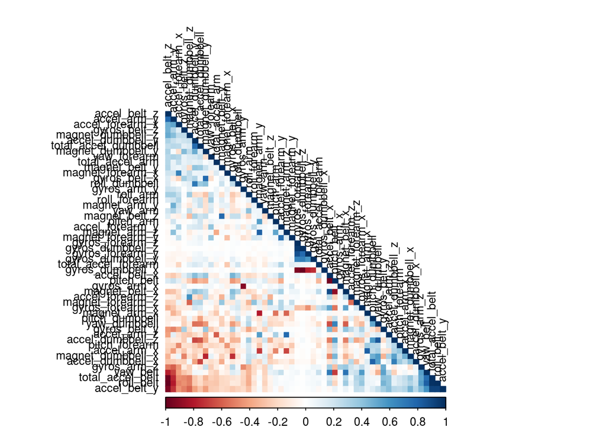

```r
corMatrix <- cor(trainingDataRelevent[, -53])
corrplot(corMatrix, order = "FPC", method = "color", type = "lower",
         tl.cex = 0.8, tl.col = rgb(0, 0, 0))
```

```r
corrMatrix <- cor(na.omit(trainingDataRelevent[sapply(trainingDataRelevent, is.numeric)]))
dim(corrMatrix)
```

```
## [1] 52 52
```

```r
# Remove Predictors with high correlations-90
removecor = findCorrelation(corrMatrix, cutoff = .90, verbose = TRUE)
```

```
## Compare row 10  and column  1 with corr  0.992
##   Means:  0.269 vs 0.168 so flagging column 10
## Compare row 1  and column  9 with corr  0.925
##   Means:  0.249 vs 0.164 so flagging column 1
## Compare row 9  and column  4 with corr  0.927
##   Means:  0.232 vs 0.161 so flagging column 9
## Compare row 8  and column  2 with corr  0.965
##   Means:  0.243 vs 0.158 so flagging column 8
## Compare row 19  and column  18 with corr  0.919
##   Means:  0.09 vs 0.158 so flagging column 18
## Compare row 46  and column  31 with corr  0.939
##   Means:  0.102 vs 0.161 so flagging column 31
## Compare row 46  and column  33 with corr  0.952
##   Means:  0.084 vs 0.164 so flagging column 33
## All correlations <= 0.9
```

```r
trainingDataCorr = trainingDataRelevent[,-removecor]
dim(trainingDataCorr)
```

```
## [1] 13737    46
```

## Development of Prediction Algrothim

Three methods will be applied to model the regressions (in the trainingDataCorr dataset). The three models will be cross validated on the validation dataset. The models applied to the Test dataset. The model with the highest accuracy will be used for the quiz predictions. The methods are: Decision Tree, Random Forest and Generalized Boosted Model.

A Confusion Matrix is plotted at the end of each analysis to better visualize the accuracy of the models.

# Decision Tree prediction model development

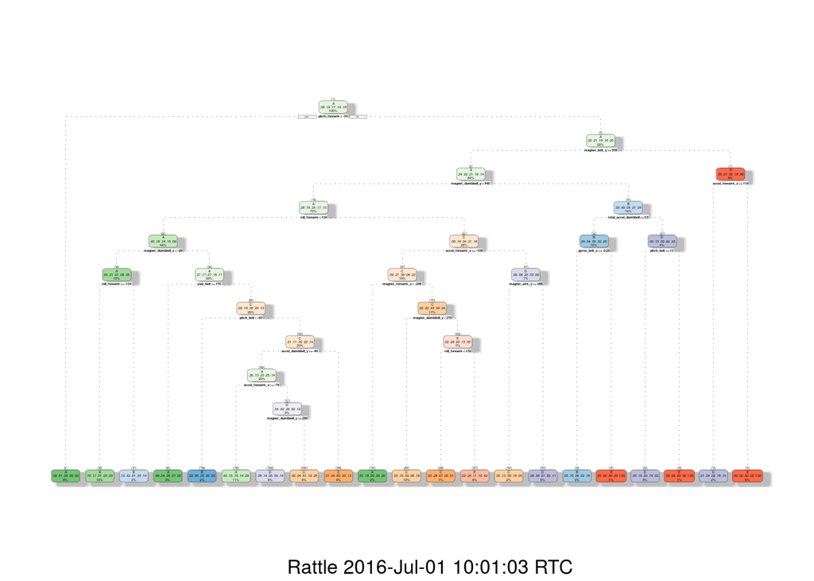

```r
set.seed(11111)
fitModel<- rpart(classe ~ ., data=trainingDataCorr, method="class")
fancyRpartPlot(fitModel)
```

# Cross Validation of the decision tree prediction using confusion Matrix

```r
treePred <- predict(fitModel, newdata=validation, type="class")
confMatPredTree<- confusionMatrix(treePred, validation$classe)
confMatPredTree
```

```
## Confusion Matrix and Statistics
##
##           Reference
## Prediction    A    B    C    D    E
##          A 1542  256  159  114  103
##          B   51  502   48   67  133
##          C   29  172  761  118  163
##          D   50   88   24  599   84
##          E    2  121   34   66  599
##
## Overall Statistics
##
##                Accuracy : 0.6802
##                  95% CI : (0.6681, 0.6921)
##     No Information Rate : 0.2845
##     P-Value [Acc > NIR] : < 2.2e-16
##
##                   Kappa : 0.5913
##  Mcnemar's Test P-Value : < 2.2e-16
##
## Statistics by Class:
##
##                      Class: A Class: B Class: C Class: D Class: E
## Sensitivity            0.9211   0.4407   0.7417   0.6214   0.5536
## Specificity            0.8499   0.9370   0.9008   0.9500   0.9536
## Pos Pred Value         0.7093   0.6267   0.6122   0.7089   0.7287
## Neg Pred Value         0.9644   0.8747   0.9429   0.9276   0.9046
## Prevalence             0.2845   0.1935   0.1743   0.1638   0.1839
## Detection Rate         0.2620   0.0853   0.1293   0.1018   0.1018
## Detection Prevalence   0.3694   0.1361   0.2112   0.1436   0.1397
## Balanced Accuracy      0.8855   0.6889   0.8213   0.7857   0.7536
```

# Plot of Decision Tree predictor

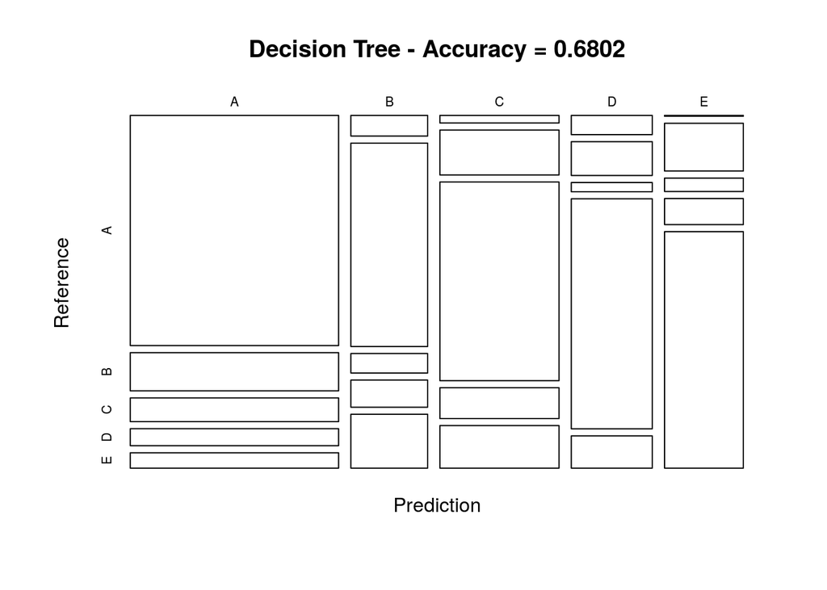

```r
plot(confMatPredTree$table, col = confMatPredTree$byClass,
     main = paste("Decision Tree - Accuracy =",
                  round(confMatPredTree$overall['Accuracy'], 4)))
```